# Estudio de la Relación Entre los Precios de Vivienda y sus Características de Propiedad Durante el Año 2019 en Lima

```r
# Filtrar los datos para eliminar filas con valores NA
filtered_data <- na.omit(urbania_data)
# Calcular los porcentajes de propiedades con y sin piscina en cada sector
amoblado_sector <- prop.table(table(filtered_data$Amoblado, filtered_data$Sector), margin = 2)
# Mostrar los porcentajes en forma de tabla
amoblado_sector
```

```
##
##                LIMA CENTRO  LIMA ESTE LIMA NORTE LIMA SUR Y BALNEARIOS
##   No            0.54508566 0.62552301 0.47813411            0.46422018
##   NoEspecifica  0.40802525 0.30543933 0.48396501            0.37798165
##   Sí            0.04688909 0.06903766 0.03790087            0.15779817
##
##                     OTROS
##   No           0.30321782
##   NoEspecifica 0.20420792
##   Sí           0.49257426
```

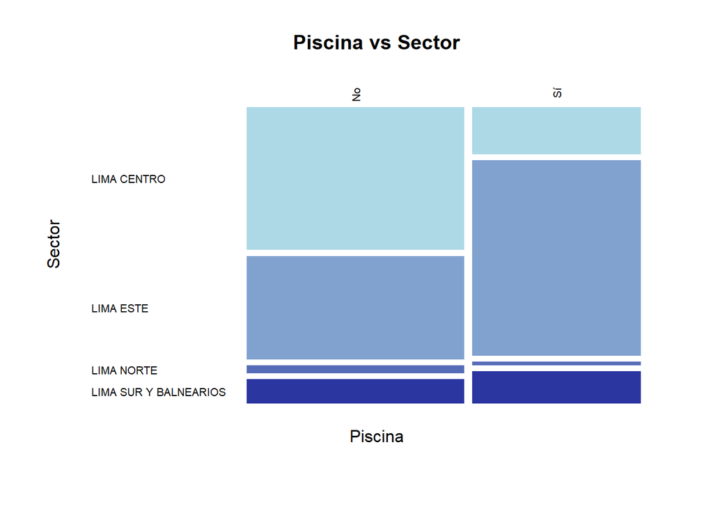

```r
#Mosaico PISCINA - SECTOR
urbania_data$Piscina[urbania_data$Piscina == "0"] <- "No"
urbania_data$Piscina[urbania_data$Piscina == "1"] <- "Sí"
color_palette <- colorRampPalette(c("lightblue", "darkblue"))(length(unique(urbania_data$Sector)))
mosaicplot(table(urbania_data$Piscina,urbania_data$Sector)[-2,1:4], las = 2, color = color_palette, main="Piscina vs Sector", xlab="Piscina", ylab = "Sector", border = "NA")
```

```r
# Filtrar los datos para eliminar filas con valores NA
filtered_data <- na.omit(urbania_data)
# Calcular los porcentajes de propiedades con y sin piscina en cada sector
piscina_sector <- prop.table(table(filtered_data$Piscina, filtered_data$Sector), margin = 2)
# Mostrar los porcentajes en forma de tabla
piscina_sector
```

```
##
##                LIMA CENTRO  LIMA ESTE LIMA NORTE LIMA SUR Y BALNEARIOS
##   No            0.43507665 0.29623431 0.14868805            0.30458716
##   NoEspecifica  0.45220920 0.26903766 0.79300292            0.38899083
##   Sí            0.11271416 0.43472803 0.05830904            0.30642202
##
##                     OTROS
##   No           0.19430693
##   NoEspecifica 0.10148515
##   Sí           0.70420792
```

- **Lima Centro:** El 43.5% de las propiedades en Lima Centro no tienen piscina, mientras que el 11.3% sí tienen piscina. Esto sugiere que la presencia de piscinas en las propiedades de esta zona es relativamente baja en comparación con otras áreas.
- **Lima Este:** En Lima Este, el 29.6% de las propiedades no cuentan con piscina, mientras que un significativo 43.5% sí tienen piscina. Esto indica que en esta zona existe una mayor proporción de propiedades con piscina en comparación con otras áreas.
- **Lima Norte:** En Lima Norte, el 14.9% de las propiedades no tienen piscina, mientras que solo el 5.8% cuentan con piscina. Esto muestra que la presencia de piscinas en las propiedades de esta zona es bastante baja en comparación con otras áreas.
- **Lima Sur y Balnearios:** En esta zona, el 30.5% de las propiedades no tienen piscina, mientras que el 30.6% sí tienen piscina. Esto indica una distribución relativamente equilibrada en términos de la presencia de piscinas en las propiedades.

## 4. **CONCLUSIONES**

Basado en el estudio realizado sobre la relación entre los precios de los inmuebles y sus características principales, se han obtenido las siguientes conclusiones:

- Existe una relación significativa entre la ubicación del inmueble y su precio. Los precios tienden a ser más altos en áreas consideradas como deseables o de alta demanda.
- Contrario a las expectativas, la antigüedad del inmueble no es un factor determinante en los precios. Otros aspectos, como la amplitud y los bienes incluidos dentro del inmueble, tienen una mayor influencia en la determinación del precio.
- Se ha identificado un sector específico en Lima con una mayor concentración de viviendas con precios elevados. Esta información permite comparar el valor relativo de las propiedades en esa área particular.

El estudio confirma que la ubicación del inmueble influye significativamente en su precio, mientras que la antigüedad no es un factor determinante. Además, se ha identificado un sector en Lima con una mayor concentración de viviendas de alto precio, lo que proporciona información relevante sobre la dinámica de precios en esa área específica.